# Project: Investigate a Dataset - [Movie Data(tmdb-movies.csv)]

- Introduction
- Data Wrangling
- Exploratory Data Analysis
- Conclusions

## Introduction

### Dataset Description

This data set contains information about 10,000 movies collected from The Movie Database (TMDb), including user ratings and revenue.

The attributes in this dataset are id, imdb_id, popularity, budget, revenue, original_title, cast, homepage, director, tagline, keywords, overview, runtime, genres, production_companies, release_date, vote_count, vote_average, release_year, budget_adj, revenue_adj.

Certain columns, like ‘cast’ and ‘genres’, contain multiple values separated by pipe (|) characters. The final two columns ending with “_adj” show the budget and revenue of the associated movie in terms of 2010 dollars, accounting for inflation over time.

### Question(s) for Analysis

The question for this analysis is

**What drives movie revenue?**

```python
import pandas as pd
import numpy as np
import matplotlib.pyplot as plt
import seaborn as sns
```

## Data Wrangling

```python
movie_df = pd.read_csv("tmdb-movies.csv")
movie_df.head()
```

|  | id | imdb_id | popularity | budget | revenue | original_title | cast | homepage | director | tagline | ... | overview | runtime | genres | production_companies | release_date | vote_count | vote_average | release_year | budget_adj | revenue_adj |
| --- | --- | --- | --- | --- | --- | --- | --- | --- | --- | --- | --- | --- | --- | --- | --- | --- | --- | --- | --- | --- | --- |
| 0 | 135397 | tt0369610 | 32.985763 | 150000000 | 1513528810 | Jurassic World | Chris Pratt\|Bryce Dallas Howard\|Irrfan Khan\|Vi... | http://www.jurassicworld.com/ | Colin Trevorrow | The park is open. | ... | Twenty-two years after the events of Jurassic ... | 124 | Action\|Adventure\|Science Fiction\|Thriller | Universal Studios\|Amblin Entertainment\|Legenda... | 6/9/15 | 5562 | 6.5 | 2015 | 1.379999e+08 | 1.392446e+09 |
| 1 | 76341 | tt1392190 | 28.419936 | 150000000 | 378436354 | Mad Max: Fury Road | Tom Hardy\|Charlize Theron\|Hugh Keays-Byrne\|Nic... | http://www.madmaxmovie.com/ | George Miller | What a Lovely Day. | ... | An apocalyptic story set in the furthest reach... | 120 | Action\|Adventure\|Science Fiction\|Thriller | Village Roadshow Pictures\|Kennedy Miller Produ... | 5/13/15 | 6185 | 7.1 | 2015 | 1.379999e+08 | 3.481613e+08 |
| 2 | 262500 | tt2908446 | 13.112507 | 110000000 | 295238201 | Insurgent | Shailene Woodley\|Theo James\|Kate Winslet\|Ansel... | http://www.thedivergentseries.movie/#insurgent | Robert Schwentke | One Choice Can Destroy You | ... | Beatrice Prior must confront her inner demons ... | 119 | Adventure\|Science Fiction\|Thriller | Summit Entertainment\|Mandeville Films\|Red Wago... | 3/18/15 | 2480 | 6.3 | 2015 | 1.012000e+08 | 2.716190e+08 |
| 3 | 140607 | tt2488496 | 11.173104 | 200000000 | 2068178225 | Star Wars: The Force Awakens | Harrison Ford\|Mark Hamill\|Carrie Fisher\|Adam D... | http://www.starwars.com/films/star-wars-episod... | J.J. Abrams | Every generation has a story. | ... | Thirty years after defeating the Galactic Empi... | 136 | Action\|Adventure\|Science Fiction\|Fantasy | Lucasfilm\|Truenorth Productions\|Bad Robot | 12/15/15 | 5292 | 7.5 | 2015 | 1.839999e+08 | 1.902723e+09 |
| 4 | 168259 | tt2820852 | 9.335014 | 190000000 | 1506249360 | Furious 7 | Vin Diesel\|Paul Walker\|Jason Statham\|Michelle ... | http://www.furious7.com/ | James Wan | Vengeance Hits Home | ... | Deckard Shaw seeks revenge against Dominic Tor... | 137 | Action\|Crime\|Thriller | Universal Pictures\|Original Film\|Media Rights ... | 4/1/15 | 2947 | 7.3 | 2015 | 1.747999e+08 | 1.385749e+09 |

5 rows × 21 columns

```python
movie_df.columns
```

```
Index(['id', 'imdb_id', 'popularity', 'budget', 'revenue', 'original_title',
       'cast', 'homepage', 'director', 'tagline', 'keywords', 'overview',
       'runtime', 'genres', 'production_companies', 'release_date',
       'vote_count', 'vote_average', 'release_year', 'budget_adj',
       'revenue_adj'],
      dtype='object')
```

The cell above displays the names of all the columns in the dataset.

```python
movie_df.shape
```

```
(10866, 21)
```

The cell above tell us the number of observations in this dataset is 10,866 and the number of columns is 21.

```python
movie_df.info()
```

```
<class 'pandas.core.frame.DataFrame'>
RangeIndex: 10866 entries, 0 to 10865
Data columns (total 21 columns):
 #   Column                Non-Null Count  Dtype
---  ------                --------------  -----
 0   id                    10866 non-null  int64
 1   imdb_id               10856 non-null  object
 2   popularity            10866 non-null  float64
 3   budget                10866 non-null  int64
 4   revenue               10866 non-null  int64
 5   original_title        10866 non-null  object
 6   cast                  10790 non-null  object
 7   homepage              2936 non-null   object
 8   director              10822 non-null  object
 9   tagline               8042 non-null   object
 10  keywords              9373 non-null   object
 11  overview              10862 non-null  object
 12  runtime               10866 non-null  int64
 13  genres                10843 non-null  object
 14  production_companies  9836 non-null   object
 15  release_date          10866 non-null  object
 16  vote_count            10866 non-null  int64
 17  vote_average          10866 non-null  float64
 18  release_year          10866 non-null  int64
 19  budget_adj            10866 non-null  float64
 20  revenue_adj           10866 non-null  float64
dtypes: float64(4), int64(6), object(11)
memory usage: 1.7+ MB
```

The cell above displays all the columns, the number of observations that are not missing and the data type of each column.

### Data Cleaning

```python
movie_df.isna().sum()
```

```
id                         0
imdb_id                   10
popularity                 0
budget                     0
revenue                    0
original_title             0
cast                      76
homepage                7930
director                  44
tagline                 2824
keywords                1493
overview                   4
runtime                    0
genres                    23
production_companies    1030
release_date               0
vote_count                 0
vote_average               0
release_year               0
budget_adj                 0
revenue_adj                0
dtype: int64
```

This cell checks for all the missing values in each column of the dataset and displays the sum.

```python
movie_dfc = movie_df.drop(['production_companies', 'keywords', 'tagline', 'homepage'], axis = 1)
```

The columns 'production_companies', 'keywords', 'tagline', 'homepage' will not be necessary in this analysis and they have quite a good number of missing values especially the 'homepage' column hence, I droped them and saved the new dataframe to 'movie_dfc'.

```python
movie_dfc.duplicated().sum()
```

```
1
```

```python
movie_dfc.drop_duplicates(inplace=True)
```

There was only one duplicate in this dataset and I droped it in the cell above inplace which removes it from the movie_dfc dataframe.

## Exploratory Data Analysis

### What drives movie revenue?

```python
movie_dfc[['popularity', 'budget', 'revenue', 'release_year']].describe()
```

|  | popularity | budget | revenue | release_year |
| --- | --- | --- | --- | --- |
| count | 10865.000000 | 1.086500e+04 | 1.086500e+04 | 10865.000000 |
| mean | 0.646446 | 1.462429e+07 | 3.982690e+07 | 2001.321859 |
| std | 1.000231 | 3.091428e+07 | 1.170083e+08 | 12.813260 |
| min | 0.000065 | 0.000000e+00 | 0.000000e+00 | 1960.000000 |
| 25% | 0.207575 | 0.000000e+00 | 0.000000e+00 | 1995.000000 |
| 50% | 0.383831 | 0.000000e+00 | 0.000000e+00 | 2006.000000 |
| 75% | 0.713857 | 1.500000e+07 | 2.400000e+07 | 2011.000000 |
| max | 32.985763 | 4.250000e+08 | 2.781506e+09 | 2015.000000 |

This cell above displays the summary statistics for all the columns analysed in the dataset.

```python
movie_dfc = movie_dfc.loc[movie_dfc.budget > 10]
```

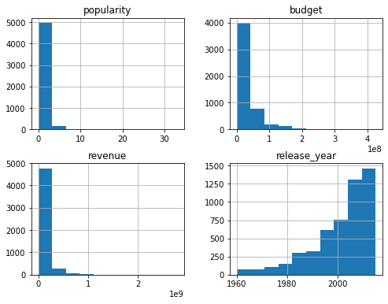

```python
movie_dfc[['popularity', 'budget', 'revenue', 'release_year']].hist(bins = 10, figsize = (8,6))
plt.show()
```

```python
movie_br = movie_dfc[['budget', 'revenue']]
movie_br.corr()
```

|  | budget | revenue |
| --- | --- | --- |
| budget | 1.000000 | 0.699827 |
| revenue | 0.699827 | 1.000000 |

I created a subset of the 'movie_dfc' dataframe to have just the 'budget' and 'revenue' columns and called the subset 'movies_br' and checked for the correlation coefficient.

The persons correlation coefficient of 0.69 shows that there is a reasonable positive correlation between budget for movies and the corresponding revenue.

```python
def sns_scatter(x, y, data, t):
    g = sns.relplot(x = x, y = y, data = data, kind = 'scatter')

    g.fig.suptitle(t.title())
    return plt.show()
```

I created a function to create scatter plots in the cell above.

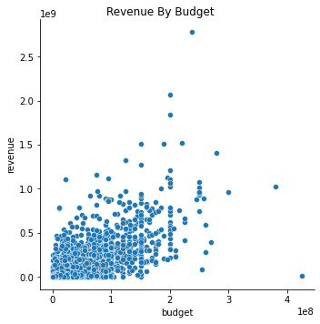

```python
sns_scatter('budget', 'revenue',movie_dfc, 'revenue by budget')
```

The scatter plot above does show some correlation also however, we can clearly see that the highest budget does not correlate to the highest revenue.

We can also see that the budget for most moveis are less than 200,000,000 and the revenue for most movies are 500,000,000 and below.

```python
movie_br.max()
```

```
budget      425000000
revenue    2781505847
dtype: int64
```

The cell above displays the maximum value for budget and revenue

```python
movie_br.loc[movie_br.revenue == 2781505847]
```

|  | budget | revenue |
| --- | --- | --- |
| 1386 | 237000000 | 2781505847 |

The cell above displays the budget and revenue for the maximum revenue in the dataset.

The budget that produced the maximum revenue in this dataset is 237million giving a revenue of over 2.7 billion.

```python
movie_br.loc[movie_br.budget == 425000000]
```

|  | budget | revenue |
| --- | --- | --- |
| 2244 | 425000000 | 11087569 |

The cell above displays the budget and revenue for the maximum budget in the dataset.

```python
movie_dfc.loc[movie_br.revenue == 2781505847, 'release_year']
```

```
1386    2009
Name: release_year, dtype: int64
```

The cell above displays the release year, in this case 2009 of the movie with the maximum revenue in this dataset.

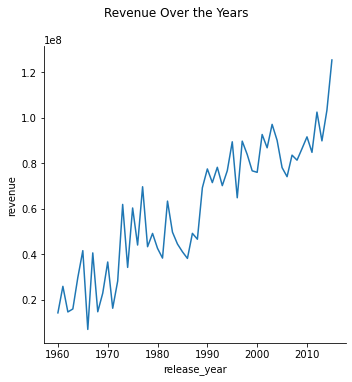

```python
g = sns.relplot('release_year', 'revenue', data = movie_dfc, kind = 'line', ci = None)

g.fig.suptitle('Revenue Over the Years', y = 1.05)
plt.show()
```

```python
movie_pr = movie_dfc[['popularity', 'revenue']]
movie_pr.corr()
```

|  | popularity | revenue |
| --- | --- | --- |
| popularity | 1.000000 | 0.638847 |
| revenue | 0.638847 | 1.000000 |

In the cell above I created a subset of the 'movie_dfc' dataframe containing 'popularity', 'revenue' and named it 'movie_pr'.

The persons correlation coefficient of 0.64 shows that there is a positive correlation between the popularity of movies and the revenue but the correlation is not very strong.

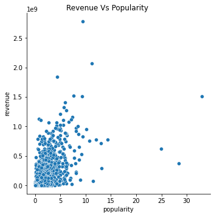

```python
sns_scatter('popularity', 'revenue', movie_pr, 'revenue vs popularity')
```

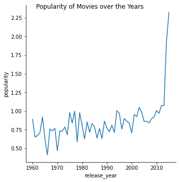

```python
g = sns.relplot(x = 'release_year', y = 'popularity', data = movie_dfc, kind = 'line', ci = None)

g.fig.suptitle('Popularity of Movies over the Years')
plt.show()
```